# Seminar 1

SOK-2011

Author

Andrea Mannberg

I oppgave 1 - 4 vil vi bruke R-studio til å se på økonomisk vekst og ulikhet. Vi vil bruke følgende pakker:

```r
suppressPackageStartupMessages(library(dplyr))
suppressPackageStartupMessages(library(plyr))
suppressPackageStartupMessages(library(ggplot2))
suppressPackageStartupMessages(library(WDI))
suppressPackageStartupMessages(library(tidyverse))
suppressPackageStartupMessages(library(countrycode))
suppressPackageStartupMessages(library(scales))
suppressPackageStartupMessages(library(tidyr))
suppressPackageStartupMessages(library(ineq))
suppressPackageStartupMessages(library(reshape2))
```

## Oppgave 1

Tegn en graf over **vekst** i BNP per innbygger i USA og China i tidsperioden 2000-2019.

Bruk variabelen “NY.GDP.PCAP.KD”(BNP per innbygger målt i konstante 2015 USD) fra pakken “WDI” (World Development Indicators, fra Verdensbanken)

```r
WDIsearch(string = "NY.GDP.PCAP.KD", field = "name", short = TRUE, cache = NULL)
```

```
[1] indicator name
<0 rows> (or 0-length row.names)
```

```r
df_gdp<-WDI(
  country = c("CN", "US"),
  indicator = c('gdppc'="NY.GDP.PCAP.KD"),
  start = 2000,
  end = 2019,
  extra = FALSE,
  latest = NULL,
  language = "en"
)
```

Det første vi skal gjøre er å se på vekstraten i BNP per innbygger i China og USA. For å gjøre dette må vi beregne vekstraten:

```r
# Vekst i BNP per innbygger

df_growth = df_gdp %>%
  arrange(iso3c, year) %>%  # Sorter pC% C%r og land
  ddply("iso3c",transform,
        gdpgrowth=c(NA,diff(log(gdppc)))*100) %>%  # Crlig vekstrate i gdppc
  mutate(gdpgrowth = as.numeric(gdpgrowth, na.rm = TRUE))
```

Nå kan vi plotte vekstraten i BNP per innbygger i China og USA i tidsperioden 2000-2019

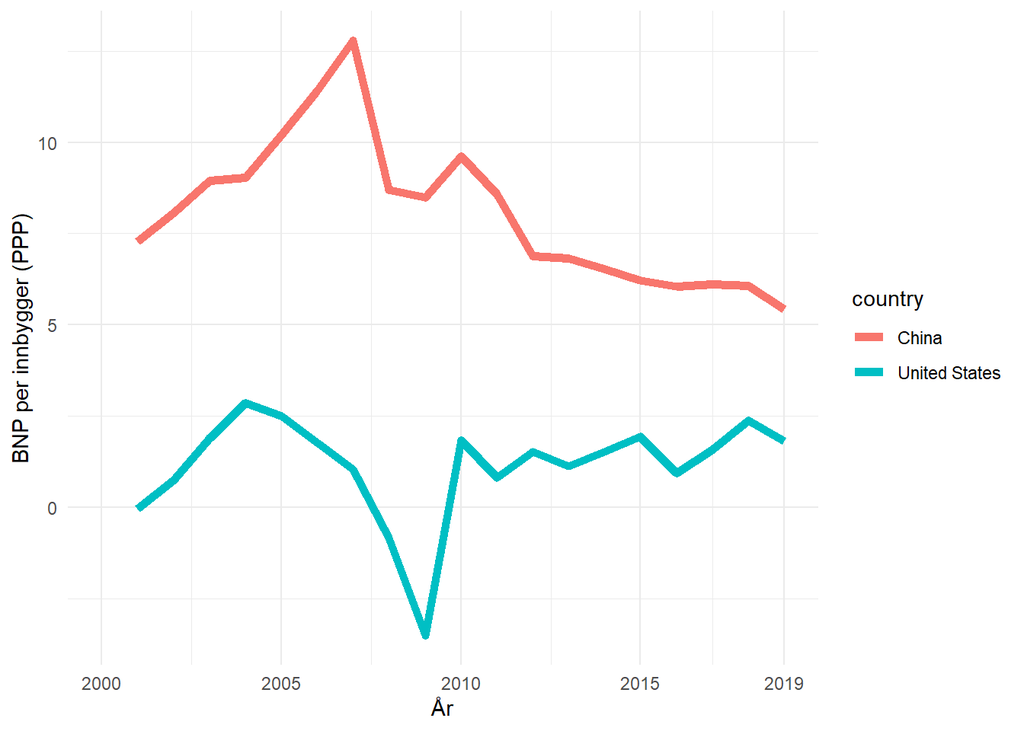

```r
plot_growth <- ggplot(df_growth, aes(x = year , y = gdpgrowth, na.rm = TRUE)) +
  xlab("År") +
  ylab("BNP per innbygger (PPP)") +
  geom_line(aes(color = country), lwd=2) +
  scale_x_continuous(breaks=c(2000, 2005, 2010, 2015, 2019)) +
  theme_minimal()
plot_growth
```

- Tolk grafen. Vokste China raskere eller langsommere enn USA i denne perioden? Dersom vi ser pC% **nivået** i BNP per innbygger, hva forventer vi oss å se i forhold til forskjellen i BNP per innbygger mellom USA og China?

## Oppgave 2

Tegn en graf over **nivå** pC% BNP per innbygger i China og USA i tidsperioden 2000-2019. Bruk variablene NY.GDP.PCAP.KD og NY.GDP.PCAP.PP.KD (PPP 2017).

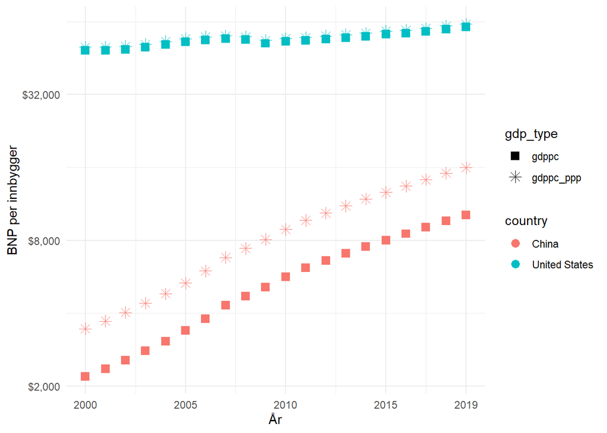

```r
df_gdp_1<-WDI(
  country = c("CN", "US"),
  indicator = c('gdppc'="NY.GDP.PCAP.KD", 'gdppc_ppp'="NY.GDP.PCAP.PP.KD"),
  start = 2000,
  end = 2019,
  extra = FALSE,
  latest = NULL,
  language = "en"
)

# vi ønsker å ha med både BNP per innbygger i konstante USD og PPP-justert BNP per innbygger. For å ha med begge i vår graf, må vi transformere data.

data_long <- gather(df_gdp_1, gdp_type, gdp, gdppc:gdppc_ppp, factor_key=TRUE)
#View (data_long)
data_long <- data_long %>%
  arrange(country, year)

# Graf over BNP per innbygger i USA og China
plot_gdp <- ggplot(data_long, aes(x = year , y = gdp, group=gdp_type)) +
  xlab("År") +
  ylab("BNP per innbygger") +
  geom_point(aes(shape=gdp_type, color = country), size=3) +
  scale_y_continuous(trans = 'log2', labels = dollar, breaks=c(500, 2000, 8000, 32000, 120000)) +
  scale_x_continuous(breaks=c(2000, 2005, 2010, 2015, 2019)) +
  scale_shape_manual(values = c(15, 8)) +
  theme_minimal()
#Display the plot
plot_gdp
```

#### Oppgave 2a

Stemte dine prediksjoner fra oppgave 1?

#### Oppgave 2b

Hvorfor er avstanden mellom China og USA mindre når vi måer BNP per innbygger med gdp_ppp (kjøpkraftsjustert) enn da vi måler BNP per innbygger med BNP målt i konstante USA-dollar?

## Oppgave 3

- Beregn gjennomsnittligårlig vekst i BNP per innbygger for perioden 2000-2019 for USA og China.
- Behold siste året (2019) for China og USA

```r
# Gjennomsnittlig årlig vekst i BNP per innbygger

df_growth_1 = df_growth %>%
  arrange(iso3c, year) %>%  # Sorter på år og land
  group_by(iso3c)  %>%
  ddply("iso3c",transform,
        avg_gdpgrowth=mean(gdpgrowth, na.rm = TRUE))


df_growth2019 = df_growth_1 %>%
  arrange(iso3c, year) %>%
  group_by(iso3c) %>%
  slice(n()) %>% # Behold den SISTE observasjonen for hvert land (2019)
  ungroup()
```

#### Oppgave 3a

Hvor lang tid vil det ta for China å dubblere BNP per innbygger, gitt at økonomien vokser med samme rate framover?

```r
# Beregne dobbleringstid for China
df_double = df_growth2019 %>%
  ddply("iso3c",transform,
        doubble=c(NA,(log(2)/(avg_gdpgrowth/100))))
  head(df_double)
```

```
        country iso2c iso3c year    gdppc gdpgrowth avg_gdpgrowth   doubble
1         China    CN   CHN 2019 10155.49  5.425442      8.064932        NA
2         China    CN   CHN 2019 10155.49  5.425442      8.064932  8.594581
3 United States    US   USA 2019 60698.01  1.813131      1.154142        NA
4 United States    US   USA 2019 60698.01  1.813131      1.154142 60.057365
```

#### Oppgave 3b

Når vil China gå om USA i BNP per innbygger, gitt at økonomien vokser med samme gjennomsnittlige vokstrate som de har gjort i de siste 20 årene?

```r
t <- (log(60698.01)-log(10155.49))/((8.064932/100)-(1.154142/100))
t
```

```
[1] 25.87109
```

## Oppgave 4

- Last ned data med inntektsfordeling [her](https://github.com/uit-sok-2011-v23/uit-sok-2011-v23.github.io/blob/main/assets/income.csv)
- Koden til denne oppgaven kommer fra [denne hjemmesiden](https://www.core-econ.org/doing-economics/book/text/05-03.html)
- Lag Lorenz kurver for USA og China i 1985 og 2015.

```r
df_income <- read_csv("C:/Users/ama123/OneDrive - UiT Office 365/Data/Undervisning/sok2011/data/income.csv", skip = 2)
#View(df_income)

#  Velg data for China og USA i C%rene 1980 og 2014
sel_Year <- c(1985, 2015)
sel_Country <- c("United States", "China")
temp <- subset(
  df_income,
  (df_income$Country %in% sel_Country) &
    (df_income$Year %in% sel_Year))
temp
```

```
# A tibble: 4 × 14
  Country   Year Decil…¹ Decil…² Decil…³ Decil…⁴ Decil…⁵ Decil…⁶ Decil…⁷ Decil…⁸
  <chr>    <dbl>   <dbl>   <dbl>   <dbl>   <dbl>   <dbl>   <dbl>   <dbl>   <dbl>
1 China     1985     125     161     198     238     282     332     394     478
2 China     2015     474     981    1525    2126    2816    3647    4719    6258
3 United …  1985    3159    5731    7957   10044   12142   14405   17056   20535
4 United …  2015    3833    6629    9201   11719   14337   17240   20726   25425
# … with 4 more variables: `Decile 9 Income` <dbl>, `Decile 10 Income` <dbl>,
#   `Mean Income` <dbl>, Population <dbl>, and abbreviated variable names
#   ¹`Decile 1 Income`, ²`Decile 2 Income`, ³`Decile 3 Income`,
#   ⁴`Decile 4 Income`, ⁵`Decile 5 Income`, ⁶`Decile 6 Income`,
#   ⁷`Decile 7 Income`, ⁸`Decile 8 Income`
# ℹ Use `colnames()` to see all variable names
```

```r
# Beregne total inntekt i landene
total_income <- temp[, "Mean Income"] *
  temp[, "Population"]
total_income
```

```
   Mean Income
1 3.909720e+11
2 7.022970e+12
3 3.797598e+12
4 6.557208e+12
```

```r
# Dette blir et svært store tall. Vi trenger egentlig ikke å ta hensyn til hele befolkninga. Det er enklere å tenke at det kun er et individ i hver desil.
# Totalt blir det da 10 personer i hver økonomi.

# Nå skal vi lage data som vi kan bruke for å tegne Lorenz kurver
# Velg desilene som hører til China. Disse er kolumn 3-12 på rad 1 (China, 1985)
decs_c85 <- unlist(temp[1, 3:12])

# 'Unlist' funksjonen transformerer temp[1, 3:12] fra en tibble til en enkel vektor med data. Dette vil gjøre beregningene enklere.

# Ta fram total inntekt, gitt antakelse om at P = 10.
total_inc <- 10 * unlist(temp[1, "Mean Income"])
# Vi vil bruke den praktiske `cumsum` funksjonen. Denne beregner kumulativ inntekt.
cum_inc_share_c85 = cumsum(decs_c85) / total_inc
cum_inc_share_c85
```

```
 Decile 1 Income  Decile 2 Income  Decile 3 Income  Decile 4 Income
      0.03360215       0.07688172       0.13010753       0.19408602
 Decile 5 Income  Decile 6 Income  Decile 7 Income  Decile 8 Income
      0.26989247       0.35913978       0.46505376       0.59354839
 Decile 9 Income Decile 10 Income
      0.75725806       1.00107527
```

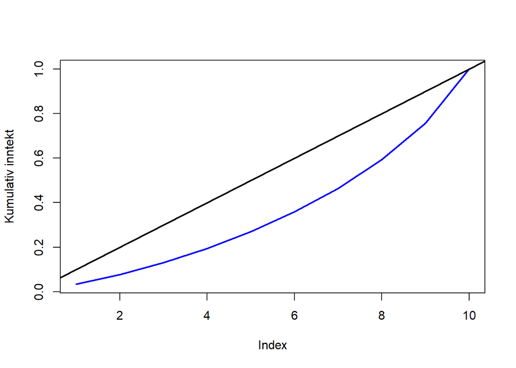

```r
# GjC8r det samme for China i 2015, og for USA i 1985 og 2015

# For China, 2015
# GC% til rad 2 (China, 2014)
decs_c15 <- unlist(temp[2, 3:12])

# Ta fram total inntekt, gitt antakelse om at P = 10.
total_inc <- 10 * unlist(temp[2, "Mean Income"])

cum_inc_share_c15 = cumsum(decs_c15) / total_inc

# For USA, 1985
# Velg rad 3 (USA, 1985)
decs_us85 <- unlist(temp[3, 3:12])

# Ta fram total inntekt, gitt antakelse om at P = 10.
total_inc <- 10 * unlist(temp[3, "Mean Income"])

cum_inc_share_us85 = cumsum(decs_us85) / total_inc

# For USA, 2015
# Velg rad 4 (USA, 2015)
decs_us15 <- unlist(temp[4, 3:12])

# Ta fram total inntekt, gitt antakelse om at P = 10.
total_inc <- 10 * unlist(temp[4, "Mean Income"])

cum_inc_share_us15 = cumsum(decs_us15) / total_inc


### Tegne Lorenz kurver
# Lage Lorenz kurven til China i 1980
plot(cum_inc_share_c85, type = "l", col = "blue",
     lwd = 2, ylab = "Kumulativ inntekt")
# Legg til en linje som viser perfekt likhet
abline(a = 0, b = 0.1, col = "black", lwd = 2)
```

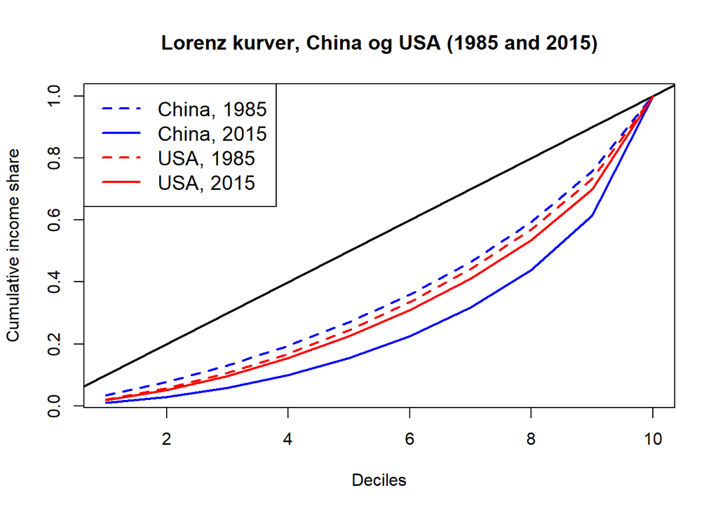

```r
# Lage kurver for China 2015, og USA 1985 og 2015

plot(cum_inc_share_c85, type = "l", col = "blue",
     lty = 2, lwd = 2, xlab = "Deciles",
     ylab = "Cumulative income share")

# Legg til en linje som viser perfekt likhet
abline(a = 0, b = 0.1, col = "black", lwd = 2)

# lty = 1 = dashed line
lines(cum_inc_share_c15, col = "blue", lty = 1, lwd = 2)

# lty = 2 = solid line
lines(cum_inc_share_us85, col = "red", lty = 2, lwd = 2)

lines(cum_inc_share_us15, col = "red",
      lty = 1, lwd = 2)

title("Lorenz kurver, China og USA (1985 and 2015)")

legend("topleft", lty = 2:1, lwd = 2, cex = 1.2, legend =
         c("China, 1985", "China, 2015",
           "USA, 1985", "USA, 2015"),
       col = c("blue", "blue", "red", "red"))
```

- Tolke kurvene, hva har skjedd med ulikheten i China og USA mellom 1985 ogo 2015?

## Oppgave 5

Gå ut ifra at en økonomis totale produksjon (BNP) kan beskrives ved bruk av produksjonsfunksjonen:
$$Y(t) = A(t)\cdot K(t)^\alpha \cdot L(t)^\beta \cdot R(t)^\gamma$$
Der $\alpha = 0.4$, $\beta = 0.5$ og $\gamma = 0.1$.

### Oppgave 5a

Med hvor mange prosent endres $Y$ dersom $K$ øker med $1\%$, ceteris paribus?

### Løsning 5a

vi ønsker å finne:
$$\frac{\partial Y}{\partial K} \cdot \frac{K}{Y}$$
Vi kan bruke to metoder for å finne svaret på spørsmålet: 1) ta det deriverte av $Y$ med hensyn på $K$ og deretter multiplisere med $K/Y$, eller, 2) logaritmer uttrykket og ta deretter det deriverte med hensyn på $K$.

Dersom vi bruker metode 2 vil vi først logartimere uttrykket:
$$ln(Y)=ln(A)+\alpha\cdot ln(K)+\beta\cdot ln(L) +\gamma \cdot ln(R)$$

Nå vil vi ta det deriverte med hensyn på $K$.

$$\frac{1}{Y}\cdot \frac{\partial Y}{\partial K} = \alpha \cdot \frac{1}{K} \cdot 1$$
$$\frac{\partial Y}{\partial K} \cdot \frac{K}{Y} = \alpha$$
$\alpha$ er den partielle produksjonselastisiteten til Kapitalet. Dersom $K$ øker med $1\%$ vil produksjonen øke med $0.4\%$, dersom $\alpha =0.4$.

## Oppgave 5b

Med hvor mange prosent endres $Y$ dersom alle produksjonsfaktorer ($K, L, R$) endres med $10\%$?

### Løsning 5b

Hva skjer dersom alle faktorer øker med samme prosent? Vi kan lage en variabel $s$ som vi bruker for å illustrere endringen. I starten er $s = 1$. Dersom alle produksjonsfaktorer øker med f.eks $10\%$ så er $s=1.1$.

$$Y(t) = A(t)\cdot(s\cdot K(t))^\alpha \cdot (s\cdot L(t))^\beta \cdot (s\cdot R(t))^\gamma$$

Dette uttrykket kan vi forenkle ved å samle termer:
$$Y(t) = A(t)\cdot K(t)^\alpha \cdot L(t)^\beta \cdot R(t)^\gamma \cdot s^{\alpha +\beta+\gamma}$$

Det vi lurer på er: med hvor mange prosent endres $Y$ dersom $s$ øker med $1\%$?

Rent matematisk søker vi etter:

$$\frac{\partial Y}{\partial s}\cdot \frac{s}{Y}$$
Dette kan vi finne ved å først logaritmere vår produksjonsfunksjon og deretter ta det deriverte med hensyn på $s$:
$$ln(Y)=ln(A)+\alpha\cdot ln(K)+\beta\cdot ln(L) +\gamma \cdot ln(R) + (\alpha +\beta +\gamma)\cdot ln(s)$$
$$\frac{\partial Y}{\partial s}\cdot \frac{1}{Y} = (\alpha +\beta +\gamma)\cdot\frac{1}{s}$$
$$\frac{\partial Y}{\partial s}\cdot \frac{s}{Y} = (\alpha +\beta +\gamma)$$
I vår oppgave er $\alpha +\beta +\gamma =1$. Dette betyr at, dersom alle produksjonsfaktorer øker med $1\%$, vil produksjonen øke med $1\%$. Dersom alle produksjonsfaktorer øker med $10\%$, vil produksjonen øke med $10\%$. Det er konstant skala-utbytte i produksjonen. I det tilfelle summen av eksponentene i produksjonsfunksjonen er mindre enn $1$ vil det være avtakende skala-utbytte.

## Oppgave 5c

Ta fram et uttrykk for vekstraten i $Y$ og tolke dette uttrykket.

### Løsning oppgave 5c:

Vekstraten gis av: $g_Y = \frac{\frac{\partial Y}{\partial t}}{Y}$

Vi kan ta fram et uttrykk for vekstraten ved bruk av den samme metoden som vi har brukt tidligere - vi logartmerer og tar det deriverte med hensyn på t.

$$g_Y = g_A +\alpha \cdot g_K + \beta \cdot g_L +\gamma \cdot g_R$$